# Estimating the proportion of cases that are reported during an outbreak

# Overview

This vignette outlines the function within `datadelay` used to estimate the proportion of cases, infections or hospitalisations ascertained.

Now we load the five key packages we need to run the commands in this vignette:

```r
library(datadelay)
library(epiparameter)
library(covidregionaldata)
library(knitr)
library(kableExtra)
```

and the four optional packages, to run the multiple examples in the last section of this vignette:

```r
library(dplyr)
library(ggplot2)
library(forcats)
library(scales)
```

# Motivation

There are several reasons why cases, infections or hospitalisations and even deaths might be under-ascertained during an outbreak of an infectious disease. Some examples include:

- Testing effort or ability is not high enough to catch all infections.
- Testing triggered by individuals rather than sampling at random in the population. This can lead to biases due to some infections either being asymptomatic or having a pre-symptomatic phase. For example, if testing is initiated by an individual who appears not to have any symptoms, it is likely the ascertainment of their infection will be delayed, or possibly missed entirely.
- Changes in the criteria, either used to diagnose the disease in question or to determine whether a death can be atttributed to the disease in question.

For example, during the recent COVID-19 pandemic, the U.K. were not able to roll out widespread testing until around May 2020. This means that during March and April, infections were significantly under-ascertained. We focus on this period within this vignette, as it illustrates the use for this analysis pipeline well.

# Methods

## Data required

The data required to estimate how the severity of a disease changes over time using the `datadelay` package includes:

- A time-series of cases, hospitalisations or some other proxy for infections over time;
- A time-series of deaths;
- A delay distribution, describing the probability an individual will die $t$ days after they were initially exposed. Such distributions come from the literature, where studies have typically fit distributions to data describing the process.

In practice, the time-series of cases and deaths will already be together, given that they usually originate from sources that will have typically collated them into a single data file.

The package requires a `data.frame` of input data — typically case and death time series data — and a delay distribution. The delay distribution we use here comes from the `epiparameter` package.

## Estimating the proportion of cases or infections that have been ascertained

The function `estimate_reporting()` from the `datadelay` package estimates the proportion of cases, infections, hospitalisations — or whichever proxy for infections is provide — which have been ascertained. The method used within this function extends the methods outlined in the previous vignettes about estimating the severity during an ongoing outbreak and measuring how the severity changes over time. Both methods are based on the Nishiura et al.<sup>[1]</sup> methods to estimate severity. We extend this by combining the resulting severity estimates with an assumed baseline severity estimate. The proportion of cases, infections or other quantity provided that have been ascertained is given by the ratio of the assumed to be true baseline severity estimate to the delay-adjusted severity estimate. The delay-adjusted severity estimates can be calculated using either the `estimate_static()` or the `estimate_time_varying()` functions.

# Example with data from the ongoing COVID-19 pandemic in the U.K.

## Downloading the raw data

```r
df_covid_uk <- get_national_data(
  countries = "united kingdom", source = "who", verbose = FALSE) |>
  dplyr::rename(cases = cases_new, deaths = deaths_new)
```

We then subset the data to focus on just the first few months of the outbreak with the following command:

```r
df_covid_uk_subset <- subset(df_covid_uk, date <= "2020-05-31")
```

## Plotting the raw data

First, we plot case incidence data with following command:

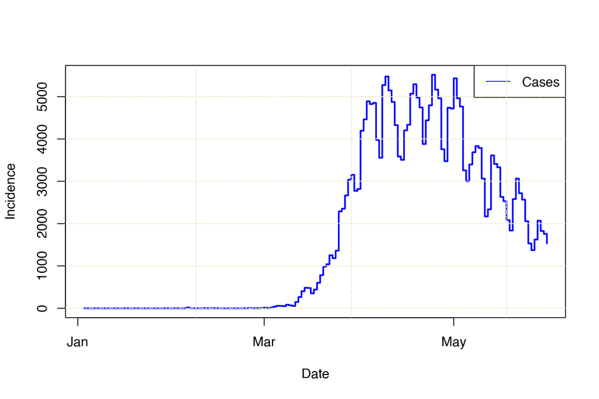

**Figure 1:** Incidence of cases over time for the ongoing COVID-19 outbreak in the U.K.

```r
plot_case_data(df_covid_uk_subset)
```

Then, we plot the death incidence data with following command:

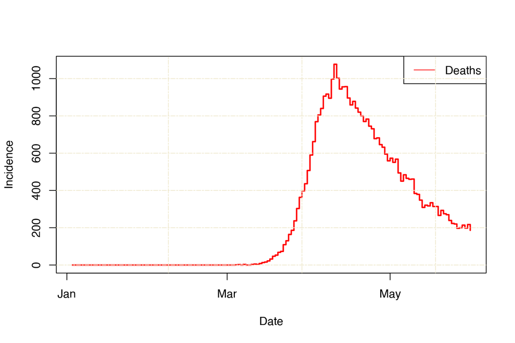

**Figure 2:** Incidence of deaths over time for the ongoing COVID-19 outbreak in the U.K.

```r
plot_death_data(df_covid_uk_subset)
```

## The delay distribution

We again retrieve the appropriate distribution — reported [here](https://doi.org/10.3390/jcm9020538)<sup>[2]</sup> — using the `epidist_db()` function from the `epiparameter` package, using the following command:

```r
onset_to_death_covid <- epidist_db(
  disease = "COVID-19",
  epi_dist = "onset_to_death",
  author = "Linton_etal"
)
```

To visualise this distribution, we evaluate it between 0 and 30 days, and plot the results over time. We do so using the following command:

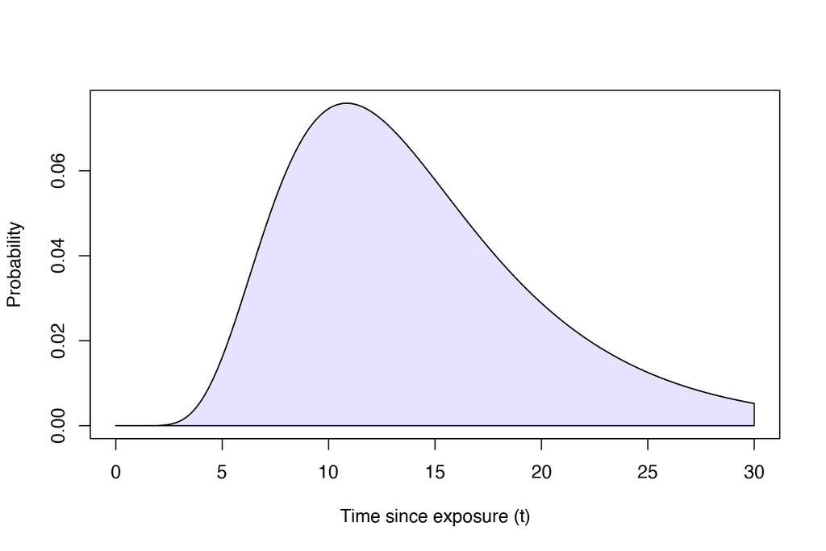

**Figure 3: Example plot of the appropriate delay distribution for the COVID-19 epidemic in the U.K.** We plot the onset-to-death distribution we use throughout this example for COVID-19, reported in https://doi.org/10.3390/jcm9020538.

```r
plot_epiparameter_distribution(onset_to_death_covid, by = 0.1)
```

## Estimating the proportion of cases that have been ascertained

```r
df_reporting_static <- estimate_reporting(df_covid_uk_subset,
                                          epi_dist = onset_to_death_covid,
                                          type = "static",
                                          severity_baseline = 0.014,
                                          correct_for_delays = TRUE) |>
  format_output(estimate_type = "reporting", type = "Under-reporting")
```

```r
df_reporting_varying <- estimate_reporting(df_covid_uk,
                                           epi_dist = onset_to_death_covid,
                                           type = "varying",
                                           severity_baseline = 0.014,
                                           smooth_inputs = TRUE,
                                           burn_in = TRUE,
                                           correct_for_delays = TRUE,
                                           custom_date = "2020-06-30") |>
  format_output(estimate_type = "reporting", type = "Under-reporting")
```

```r
knitr::kable(df_reporting_static,
  align = "c",
  col.names = c("Location", "Under-reporting estimate", "Type")) |>
  kableExtra::kable_styling(full_width = FALSE)
```

| Location | Under-reporting estimate | Type |
| --- | --- | --- |
| United Kingdom | 8.19% (95% CI: 8.14% - 8.24%) | Under-reporting |

```r
knitr::kable(df_reporting_varying,
  align = "c",
  col.names = c("Location", "Under-reporting estimate", "Type")) |>
  kableExtra::kable_styling(full_width = FALSE)
```

| Location | Under-reporting estimate | Type |
| --- | --- | --- |
| United Kingdom | 36.74% (95% CI: 27.64% - 50.13%) | Under-reporting |

# Example with all countries with large early COVID-19 outbreaks

```r
df_covid <- get_national_data(
  source = "who", verbose = FALSE) |>
  rename(cases = cases_new, deaths = deaths_new)

df_covid_subset <- subset(df_covid, date <= "2020-05-31")
```

Finally, we put the ascertainment estimates for all countries with large outbreaks in a single table and summarise the results in a single figure. We define a large outbreak as one which has caused at least 100,000 deaths. We focus on these countries as the resulting table and figure become unwieldy if they are made any larger. We focus on the period between the start of each outbreak to the 1st June 2020. We do so as it was this period where under-ascertainment of cases and infections was likely the highest, as tests were still being developed and had not been made widely available in many countries.

To calculate all ascertainment estimates for all countries with large COVID-19 outbreaks up to the 1st June 2020, we use the following command — this codeblock depends on the package `dplyr`, for ease with manipulating large data.frames which are structured by group:

```r
df_reporting <- df_covid |>
  group_by(iso_code) |>
  mutate(total_deaths = max(deaths_total)) |>
  filter(total_deaths > 100000 & !is.na(country)) |>
  filter(date < "2020-06-01") |>
  group_map(~estimate_reporting(
    df_in = .,
    epi_dist = onset_to_death_covid,
    type = "varying",
    severity_baseline = 0.014,
    burn_in = TRUE,
    smooth_inputs = TRUE,
    correct_for_delays = TRUE)) |>
  bind_rows()

df_reporting_neat <- format_output(
  df_in = df_reporting,
  estimate_type = "reporting",
  type = "Ascertainment")
```

Then, to plot all of these results on a single figure, we use the following command — this codeblock depends on the commonly used package `ggplot2`, for ease with plotting large data.frames:

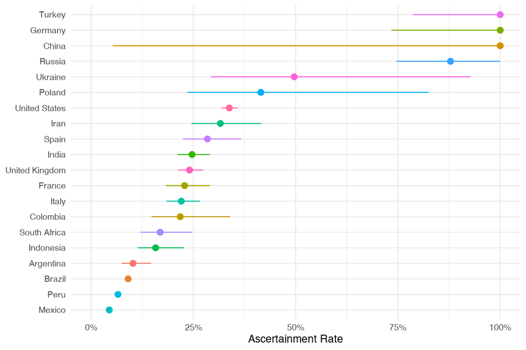

```r
df_reporting |>
  ggplot() +
  geom_pointrange(
    aes(x = fct_reorder(location, reporting_me),
        y = reporting_me,
        ymin = reporting_lo,
        ymax = reporting_hi,
        colour = location)) +
  coord_flip() +
  labs(x = NULL, y = "Ascertainment Rate") +
  theme_minimal() +
  theme(legend.position = "none") +
  scale_y_continuous(labels = percent, limits = c(0, 1))
```

Finally, we put the same results in a large table with the following command:

```r
kable(df_reporting_neat,
  align = "c",
  col.names = c("Location", "Estimate", "Type")) |>
  kable_styling(full_width = FALSE)
```

| Location | Estimate | Type |
| --- | --- | --- |
| Argentina | 10.24% (95% CI: 7.47% - 14.67%) | Ascertainment |
| Brazil | 9.06% (95% CI: 8.54% - 9.61%) | Ascertainment |
| China | 100.00% (95% CI: 5.29% - 100.00%) | Ascertainment |
| Colombia | 21.79% (95% CI: 14.76% - 34.01%) | Ascertainment |
| Germany | 100.00% (95% CI: 73.41% - 100.00%) | Ascertainment |
| Spain | 28.44% (95% CI: 22.42% - 36.73%) | Ascertainment |
| France | 22.87% (95% CI: 18.30% - 29.04%) | Ascertainment |
| United Kingdom | 24.07% (95% CI: 21.25% - 27.39%) | Ascertainment |
| Indonesia | 15.78% (95% CI: 11.44% - 22.64%) | Ascertainment |
| India | 24.68% (95% CI: 21.11% - 29.07%) | Ascertainment |
| Iran | 31.60% (95% CI: 24.50% - 41.62%) | Ascertainment |
| Italy | 22.05% (95% CI: 18.45% - 26.63%) | Ascertainment |
| Mexico | 4.44% (95% CI: 4.16% - 4.76%) | Ascertainment |
| Peru | 6.56% (95% CI: 6.10% - 7.09%) | Ascertainment |
| Poland | 41.49% (95% CI: 23.50% - 82.54%) | Ascertainment |
| Russia | 87.85% (95% CI: 74.64% - 100.00%) | Ascertainment |
| Turkey | 100.00% (95% CI: 78.68% - 100.00%) | Ascertainment |
| Ukraine | 49.65% (95% CI: 29.33% - 92.72%) | Ascertainment |
| United States | 33.78% (95% CI: 31.90% - 35.80%) | Ascertainment |
| South Africa | 16.89% (95% CI: 12.05% - 24.73%) | Ascertainment |

1

Nishiura H, Klinkenberg D, Roberts M, *et al.* Early epidemiological assessment of the virulence of emerging infectious diseases: A case study of an influenza pandemic. *PloS one* 2009;**4**:e6852.

2

Linton NM, Kobayashi T, Yang Y, *et al.* Incubation period and other epidemiological characteristics of 2019 novel coronavirus infections with right truncation: A statistical analysis of publicly available case data. *Journal of clinical medicine* 2020;**9**:538.